# HW 3, CH 6 MD HW

Matthew Swanson

20191022

# 1 Orange Juice

```r
load("OJUICE.Rdata")
head(OJUICE)
```

```
##   RUN SWEET PECTIN
## 1   1   5.2    220
## 2   2   5.5    227
## 3   3   6.0    259
## 4   4   5.9    210
## 5   5   5.8    224
## 6   6   6.0    215
```

1. Suppose a manufacturer wants to use to predict the sweetness ($y$) from the amount of pectin ($x$)
   1. Conduct Exploratory data analysis (Note: This constists of three parts)
1. Looking at the raw values:

```r
head(OJUICE)
```

```
##   RUN SWEET PECTIN
## 1   1   5.2    220
## 2   2   5.5    227
## 3   3   6.0    259
## 4   4   5.9    210
## 5   5   5.8    224
## 6   6   6.0    215
```

```r
#View(OJUICE)
```

2. Computing and describing the summary statistics likes means, medians, and standard deviations. Specially the correlation coefficient:

```r
library(skimr)
OJUICE %>% skim()
```

```
## Skim summary statistics
##  n obs: 24
##  n variables: 3
##
## ── Variable type:numeric ───────────────────────────────────────────────────────────────────────────────────────────────────────────────────────────────────────────────────────
##  variable missing complete  n   mean    sd    p0    p25   p50    p75 p100
##    PECTIN       0       24 24 256.96 49.54 210   226.25 243.5 265     410
##       RUN       0       24 24  12.5   7.07   1     6.75  12.5  18.25   24
##     SWEET       0       24 24   5.66  0.24   5.2   5.5    5.7   5.82    6
##      hist
##  ▇▅▃▁▁▁▁▁
##  ▇▇▇▇▇▇▇▇
##  ▆▂▅▅▃▇▆▃
```

```r
cor(x = OJUICE$PECTIN, y = OJUICE$SWEET)
```

```
## [1] -0.4781458
```

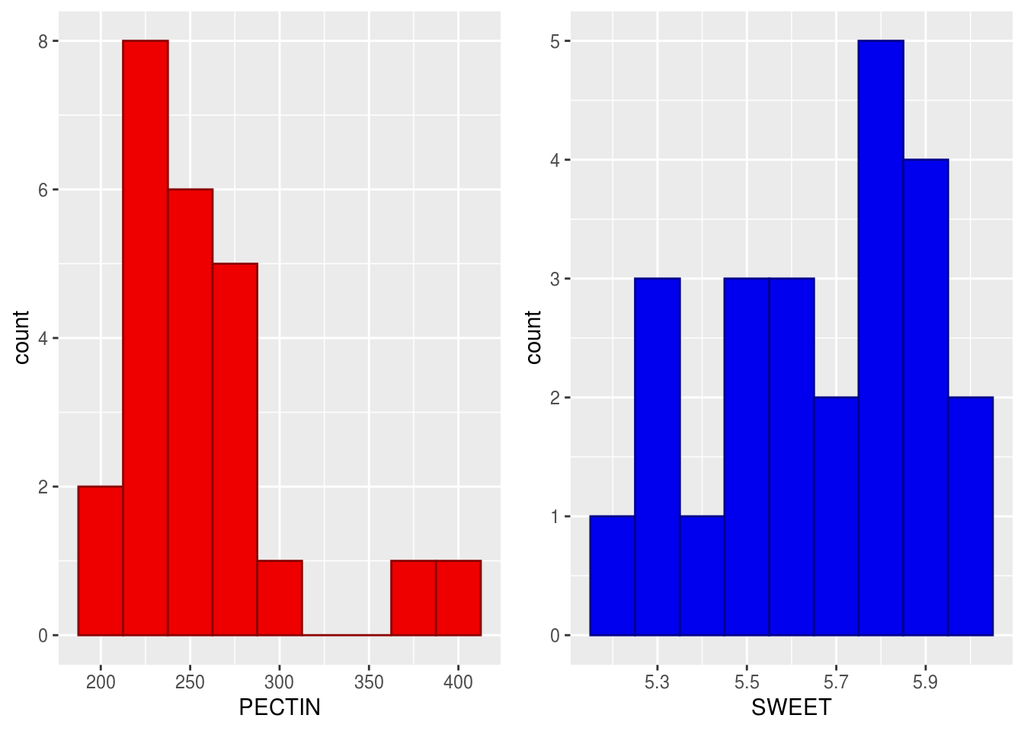

```r
library(ggplot2)
library(cowplot)
pp = ggplot(data = OJUICE, mapping = aes(x = PECTIN)) +
  geom_histogram(binwidth = 25, fill = 'red2', color = 'red4')
ps = ggplot(data = OJUICE, mapping = aes(x = SWEET)) +
  geom_histogram(binwidth = 0.1, fill = 'blue2', color = 'blue4')
plot_grid(pp, ps)
```

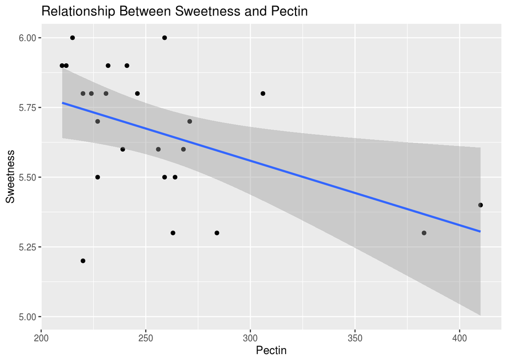

```r
ggplot(data = OJUICE, mapping = aes(x = PECTIN, y = SWEET)) +
    geom_point() +
    labs(x = "Pectin", y = "Sweetness", title = "Relationship Between Sweetness and Pectin") +
    geom_smooth(method = "lm")
```

- Most of the pectin observed values vall in between 215 and 285
- The sweetness values are pretty normally distributed, with slightly more falling between 5.7 and 6
- There is some negative correlation between sweetness and pectin
2. Fit the model and write the equation.

```r
sweet_model <- lm(SWEET ~ PECTIN, data = OJUICE) #y ~ x
sweet_model
```

```
##
## Call:
## lm(formula = SWEET ~ PECTIN, data = OJUICE)
##
## Coefficients:
## (Intercept)       PECTIN
##    6.252068    -0.002311
```

> $\hat{Sweetness} = 6.252068 - 0.002311 \cdot Pectin$
3. Give a practical interpretation of the value of b0, if possible.

> $b_0$ *is the y-intercept for our linear model. It could mean that for a pectin value of 0, you could expect a sweetness value of 6.25. However, since out lowest pectin value is around 200, that would be extrapolation, rendering* $b_0$ *as meaningless*
4. Give a practical interpretation of the value of b1, if possible.

> *Every time we increase the pectin value by 1, our expected sweetness value decreases by -0.002311*
22. Predict the sweetness index if amount of pectin in the orange juice is 300 ppm.

`> 6.252068 - 0.002311 * 300`

```
5.558768
```

6. Figure out a way to do v. in R. (We did not discussed this in class)

```r
newx = data.frame(PECTIN = 300)
predicted_sweet = predict(sweet_model, newx)
predicted_sweet
```

```
##       1
## 5.55888
```

7. Conduct diagnostics and comment on how “good” the model is.

```r
library(moderndive)
regression_points <- get_regression_points(sweet_model)
regression_points
```

```
## # A tibble: 24 x 5
##       ID SWEET PECTIN SWEET_hat residual
##    <int> <dbl>  <dbl>     <dbl>    <dbl>
##  1     1   5.2    220      5.74   -0.544
##  2     2   5.5    227      5.73   -0.228
##  3     3   6      259      5.65    0.346
##  4     4   5.9    210      5.77    0.133
##  5     5   5.8    224      5.73    0.066
##  6     6   6      215      5.76    0.245
##  7     7   5.8    231      5.72    0.082
##  8     8   5.6    268      5.63   -0.033
##  9     9   5.6    239      5.7    -0.1
## 10    10   5.9    212      5.76    0.138
## # … with 14 more rows
```

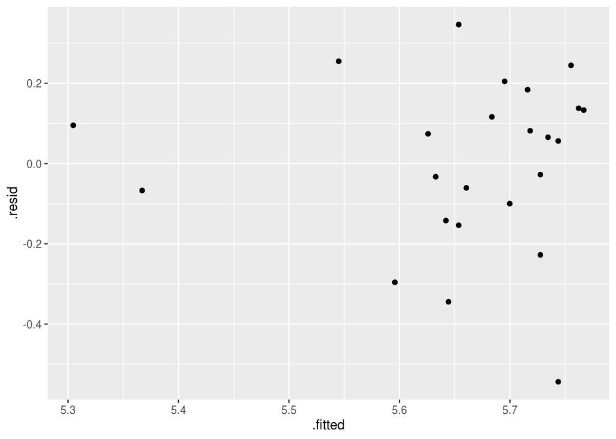

```r
ggplot(sweet_model, aes(x = .fitted, y = .resid)) + geom_point()
```

> Based on the residual plot, it seems that the model is not very good. The correlation between sweetness and pectin is too low to create an accurate linear model.

# 2 Credit

```r
library(ISLR)
data(Credit)
```

1. Suppose we want to use to predict the `Balance` ($y$) from the `Ethnicity` ($x$)
1. Conduct Exploratory data analysis
1. Looking at the raw values:

```r
head(Credit)
```

```
##   ID  Income Limit Rating Cards Age Education Gender Student Married
## 1  1  14.891  3606    283     2  34        11   Male      No     Yes
## 2  2 106.025  6645    483     3  82        15 Female     Yes     Yes
## 3  3 104.593  7075    514     4  71        11   Male      No      No
## 4  4 148.924  9504    681     3  36        11 Female      No      No
## 5  5  55.882  4897    357     2  68        16   Male      No     Yes
## 6  6  80.180  8047    569     4  77        10   Male      No      No
##   Ethnicity Balance
## 1 Caucasian     333
## 2     Asian     903
## 3     Asian     580
## 4     Asian     964
## 5 Caucasian     331
## 6 Caucasian    1151
```

```r
#View(Credit)
#Income in 10s of thousands
```

2. Computing and describing the summary statistics likes means, medians, and standard deviations. Specially the correlation coefficient:

```r
library(dplyr)
credit = Credit %>% select(Balance, Ethnicity)
credit %>% skim()
```

```
## Skim summary statistics
##  n obs: 400
##  n variables: 2
##
## ── Variable type:factor ────────────────────────────────────────────────────────────────────────────────────────────────────────────────────────────────────────────────────────
##   variable missing complete   n n_unique
##  Ethnicity       0      400 400        3
##                          top_counts ordered
##  Cau: 199, Asi: 102, Afr: 99, NA: 0   FALSE
##
## ── Variable type:integer ───────────────────────────────────────────────────────────────────────────────────────────────────────────────────────────────────────────────────────
##  variable missing complete   n   mean     sd p0   p25   p50 p75 p100
##   Balance       0      400 400 520.01 459.76  0 68.75 459.5 863 1999
##      hist
##  ▇▃▃▃▂▁▁▁
```

```r
tbl = credit %>%
    group_by(Ethnicity) %>%
    summarize(Min = min(Balance), Mean = mean(Balance), Median = median(Balance), Max = max(Balance), SD = sd(Balance), N = n())
kable(tbl)
```

| Ethnicity | Min | Mean | Median | Max | SD | N |
| --- | --- | --- | --- | --- | --- | --- |
| African American | 0 | 531.0000 | 480 | 1809 | 485.6327 | 99 |
| Asian | 0 | 512.3137 | 414 | 1779 | 481.4025 | 102 |
| Caucasian | 0 | 518.4975 | 465 | 1999 | 436.9467 | 199 |

```r
Balance_model <- lm(Balance ~ Ethnicity, data = credit)
Balance_model
```

```
##
## Call:
## lm(formula = Balance ~ Ethnicity, data = credit)
##
## Coefficients:
##        (Intercept)      EthnicityAsian  EthnicityCaucasian
##             531.00              -18.69              -12.50
```

```r
summary(Balance_model)
```

```
##
## Call:
## lm(formula = Balance ~ Ethnicity, data = credit)
##
## Residuals:
##     Min      1Q  Median      3Q     Max
## -531.00 -457.08  -63.25  339.25 1480.50
##
## Coefficients:
##                    Estimate Std. Error t value Pr(>|t|)
## (Intercept)          531.00      46.32  11.464   <2e-16 ***
## EthnicityAsian       -18.69      65.02  -0.287    0.774
## EthnicityCaucasian   -12.50      56.68  -0.221    0.826
## ---
## Signif. codes:  0 '***' 0.001 '**' 0.01 '*' 0.05 '.' 0.1 ' ' 1
##
## Residual standard error: 460.9 on 397 degrees of freedom
## Multiple R-squared:  0.0002188,  Adjusted R-squared:  -0.004818
## F-statistic: 0.04344 on 2 and 397 DF,  p-value: 0.9575
```

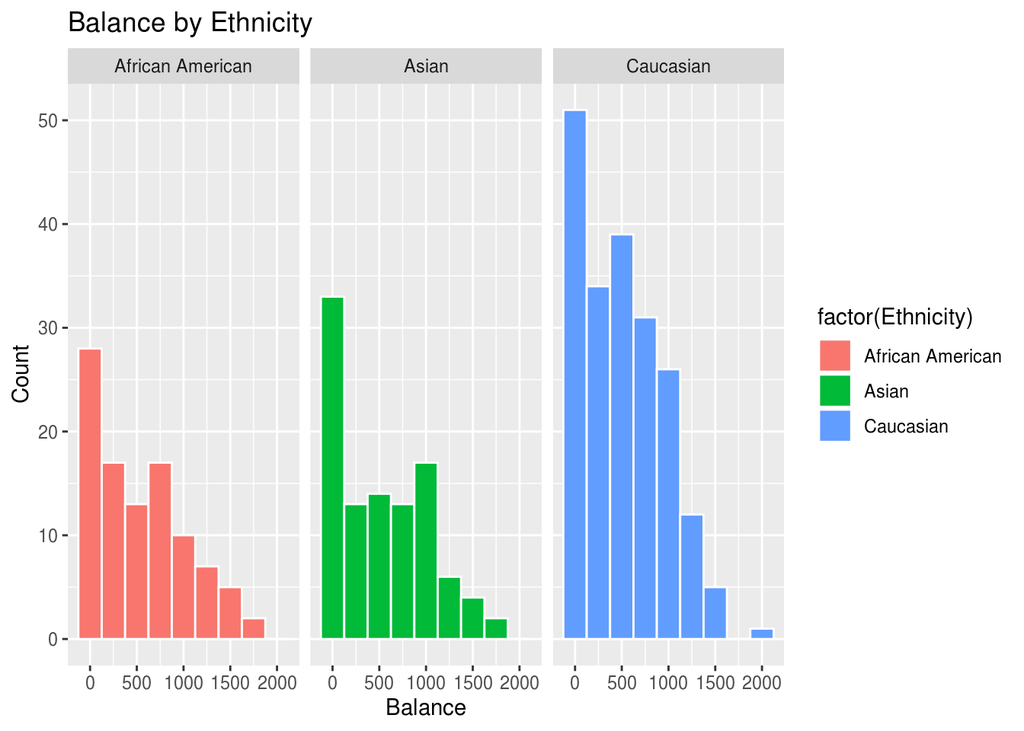

```r
ggplot(data = credit, mapping = aes(x = Balance, fill = factor(Ethnicity))) +
    geom_histogram(binwidth = 250, color = 'white') +
    labs(x = "Balance", y = "Count", title = "Balance by Ethnicity") +
    facet_wrap(~ Ethnicity, nrow = 1)
```

- Caucasians make up half of all observations
- The highest observed balance by far (~$2000) is of a Caucasian person
- Asians have more observed values around zero than AfricanAmericans
2. Fit the model and write the equation.

$\hat{Balance} = 531.00 - 18.69 \cdot 1_{Asia}(x) - 12.50 \cdot 1_{Cauc}(x)$

3. Give a practical interpretations of all coefficients and fitted values.
- $b_0 = Intercept = 531$: the mean balance for AfricanAmericans (our baseline)
- $b_{Asia} = EthnicityAsian = -18.69$: the difference in balance between Asians relative to AfricanAmericans, or in other words, on average Asians had balance $\$-18.69$ less.
- $b_{Cauc} = EthnicityCaucasian = -12.50$: the difference in balance between Caucasians relative to AfricanAmericans, or in other words, on average Caucasians had balance $\$-12.50$ less.